# The Impact of Maternal Sociodemographic Factors on Prenatal Care

# 4.2 Chi-Square Test: Plurality vs Delivery Method

We are investigating whether the number of babies delivered (plurality) is associated with the mode of delivery (delivery method).  
Both variables are categorical; therefore, a Chi-Square Test of Independence is appropriate.

## 4.2.1 Prepare Data

```r
# Prepare dataset for Chi-square analysis
chisq_data <- natality_all %>%
  select(plurality, delivery_method) %>%
  filter(!is.na(plurality) & !is.na(delivery_method))  # Remove missing values
```

## 4.2.2 Contingency Table

```r
table_chisq <- table(chisq_data$plurality, chisq_data$delivery_method)
table_chisq
```

```
##
##             C-Section Vaginal
##   Singleton     20922   46738
##   Triplet+         52       4
##   Twin           1667     571
```

## 4.2.4 Perform Chi-Square Test

```r
chisq_test_result <- chisq.test(table_chisq)
chisq_test_result
```

```
##
##  Pearson's Chi-squared test
##
## data:  table_chisq
## X-squared = 1971.8, df = 2, p-value < 2.2e-16
```

## 4.2.5 Visualize with Bar Plot

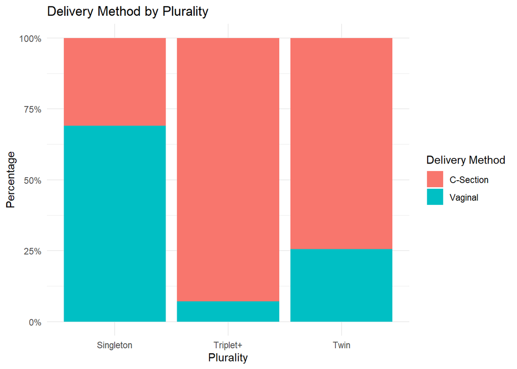

```r
ggplot(chisq_data, aes(x = plurality, fill = delivery_method)) +
  geom_bar(position = "fill") +
  scale_y_continuous(labels = scales::percent) +
  labs(
    title = "Delivery Method by Plurality",
    x = "Plurality",
    y = "Percentage",
    fill = "Delivery Method"
  ) +
  theme_minimal()
```

# 5. Multivariate Analysis: Multiple Linear Regression

## Introduction

We are modeling birthweight (in grams) as a function of several maternal and birth characteristics. A multiple linear regression will allow us to examine the independent association of each predictor with birthweight, adjusting for all other variables in the model.

## 5.1 Prepare Data

```r
# Prepare dataset for regression
regression_data <- natality_all %>%
  select(birthweight_grams, maternal_age, marital_status, education_level,
         prenatal_care_start, bmi_category, delivery_method, plurality, gestational_weeks) %>%
  filter(
    !is.na(birthweight_grams),
    !is.na(maternal_age),
    !is.na(marital_status),
    !is.na(education_level),
    !is.na(prenatal_care_start),
    !is.na(bmi_category),
    !is.na(delivery_method),
    !is.na(plurality),
    !is.na(gestational_weeks)
  )
```

## 5.2 Fit the Multiple Linear Regression Model

```r
regression_model <- lm(birthweight_grams ~ maternal_age + marital_status + education_level +
                         prenatal_care_start + bmi_category + delivery_method +
                         plurality + gestational_weeks,
                       data = regression_data)

# Display model summary
summary(regression_model)
```

```
##
## Call:
## lm(formula = birthweight_grams ~ maternal_age + marital_status +
##     education_level + prenatal_care_start + bmi_category + delivery_method +
##     plurality + gestational_weeks, data = regression_data)
##
## Residuals:
##      Min       1Q   Median       3Q      Max
## -3044.20  -302.09    -4.87   303.12  2865.16
##
## Coefficients:
##                                       Estimate Std. Error t value Pr(>|t|)
## (Intercept)                         -1303.1854    37.1271 -35.101  < 2e-16 ***
## maternal_age                            1.9282     0.3926   4.911 9.10e-07 ***
## marital_statusUnmarried               -81.4837     4.6462 -17.538  < 2e-16 ***
## education_level9–12, no diploma       -62.5845    13.3199  -4.699 2.63e-06 ***
## education_levelAssociate               -2.3257    13.2831  -0.175  0.86101
## education_levelBachelor                17.9559    12.3559   1.453  0.14617
## education_levelDoctorate                1.6089    16.4072   0.098  0.92188
## education_levelHS Grad                -39.1347    12.1080  -3.232  0.00123 **
## education_levelMaster                   8.3679    13.2272   0.633  0.52698
## education_levelSome College           -21.5213    12.3170  -1.747  0.08059 .
## prenatal_care_start2nd Trimester        5.7664     5.4035   1.067  0.28590
## prenatal_care_start3rd Trimester       -0.6734     9.5287  -0.071  0.94366
## prenatal_care_startNo Prenatal Care   -68.1824    14.7307  -4.629 3.69e-06 ***
## bmi_categoryObesity I                 103.7157     5.8849  17.624  < 2e-16 ***
## bmi_categoryObesity II                122.5980     7.6138  16.102  < 2e-16 ***
## bmi_categoryObesity III               141.0034     8.7369  16.139  < 2e-16 ***
## bmi_categoryOverweight                 72.3889     4.9198  14.714  < 2e-16 ***
## bmi_categoryUnderweight              -131.1483    11.8393 -11.077  < 2e-16 ***
## delivery_methodVaginal                 -1.5576     4.3552  -0.358  0.72062
## pluralityTriplet+                    -943.0831    69.8068 -13.510  < 2e-16 ***
## pluralityTwin                        -566.0568    11.6011 -48.793  < 2e-16 ***
## gestational_weeks                     117.0726     0.8353 140.149  < 2e-16 ***
## ---
## Signif. codes:  0 '***' 0.001 '**' 0.01 '*' 0.05 '.' 0.1 ' ' 1
##
## Residual standard error: 476.1 on 58952 degrees of freedom
## Multiple R-squared:  0.3379, Adjusted R-squared:  0.3377
## F-statistic:  1433 on 21 and 58952 DF,  p-value: < 2.2e-16
```

## 5.3 Report Coefficients with Confidence Intervals (Professional Table)

```r
library(broom)

# Create clean regression table
tidy(regression_model, conf.int = TRUE)
```

| term | estimate | std.error | statistic | p.value | conf.low | conf.high |
| --- | --- | --- | --- | --- | --- | --- |
| (Intercept) | -1303.1853805 | 37.1270578 | -35.10069094 | 3.801824e-267 | -1375.954571 | -1230.416190 |
| maternal_age | 1.9281518 | 0.3926489 | 4.91062570 | 9.102865e-07 | 1.158558 | 2.697745 |
| marital_statusUnmarried | -81.4837493 | 4.6461717 | -17.53782574 | 1.102011e-68 | -90.590265 | -72.377233 |
| education_level9–12, no diploma | -62.5845021 | 13.3199419 | -4.69855668 | 2.625968e-06 | -88.691645 | -36.477360 |
| education_levelAssociate | -2.3257145 | 13.2831238 | -0.17508792 | 8.610112e-01 | -28.360693 | 23.709264 |
| education_levelBachelor | 17.9559241 | 12.3558939 | 1.45322744 | 1.461659e-01 | -6.261680 | 42.173528 |
| education_levelDoctorate | 1.6089409 | 16.4072246 | 0.09806295 | 9.218826e-01 | -30.549289 | 33.767170 |
| education_levelHS Grad | -39.1346868 | 12.1079900 | -3.23213735 | 1.229355e-03 | -62.866398 | -15.402975 |
| education_levelMaster | 8.3678565 | 13.2272039 | 0.63262474 | 5.269812e-01 | -17.557519 | 34.293232 |
| education_levelSome College | -21.5213261 | 12.3169830 | -1.74728877 | 8.059247e-02 | -45.662665 | 2.620013 |

[output cut: 12 more lines]

## 5.4 Visualizations (Optional but Good)

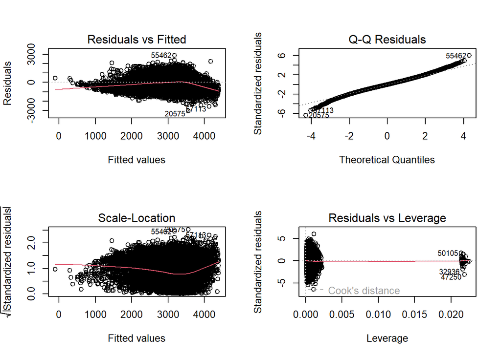

```r
par(mfrow = c(2,2))
plot(regression_model)
```

## 5.5 Forest Plot of Regression Coefficients

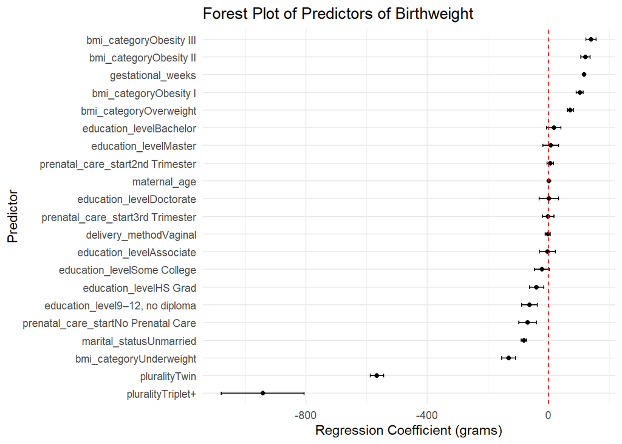

```r
library(ggplot2)
library(broom)

# Tidy the regression model output
regression_tidy <- tidy(regression_model, conf.int = TRUE)

# Remove intercept
regression_tidy <- regression_tidy %>%
  filter(term != "(Intercept)")

# Create forest plot
ggplot(regression_tidy, aes(x = estimate, y = reorder(term, estimate))) +
  geom_point() +
  geom_errorbarh(aes(xmin = conf.low, xmax = conf.high), height = 0.2) +
  geom_vline(xintercept = 0, linetype = "dashed", color = "red") +
  labs(
    title = "Forest Plot of Predictors of Birthweight",
    x = "Regression Coefficient (grams)",
    y = "Predictor"
  ) +
  theme_minimal()
```

## 5.7 Regression Diagnostics:

### 5.7.1 Normality of Residuals

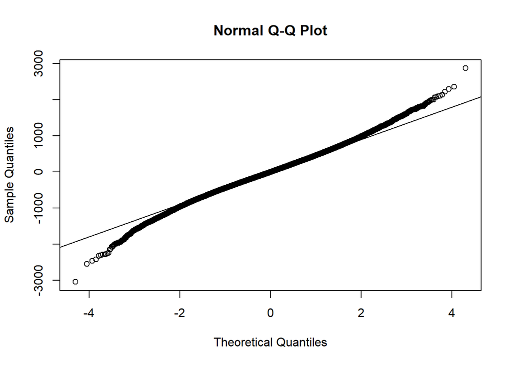

```r
# Plot QQ plot for residuals
qqnorm(residuals(regression_model))
qqline(residuals(regression_model))
```

### Interpretation: The QQ plot shows that residuals approximately follow a normal distribution, with slight deviations at the tails, which is acceptable given the large sample size.

### 5.7.2 Homoscedasticity (Equal Variance)

```r
library(lmtest)
bptest(regression_model)
```

```
##
##  studentized Breusch-Pagan test
##
## data:  regression_model
## BP = 1499.9, df = 21, p-value < 2.2e-16
```

### Interpretation:

Given the very large sample size, slight violations of homoscedasticity are common and do not severely impact the validity of coefficient estimates, especially when inference is supported by robust standard errors if needed. Therefore, results are still interpretable with caution.

### 5.7.3 Multicollinearity Check

```r
library(car)
vif(regression_model)
```

```
##                         GVIF Df GVIF^(1/(2*Df))
## maternal_age        1.333572  1        1.154804
## marital_status      1.344770  1        1.159642
## education_level     1.518701  7        1.030297
## prenatal_care_start 1.070555  3        1.011428
## bmi_category        1.076970  5        1.007443
## delivery_method     1.083769  1        1.041042
## plurality           1.093049  2        1.022492
## gestational_weeks   1.095032  1        1.046438
```

### Interpretation:

The Variance Inflation Factors (VIFs) for all predictors were low, with values close to 1 and none exceeding 2. This indicates that there is no concerning multicollinearity among the independent variables included in the regression model.

## Results of Regression Diagnostics:

Model assumptions were evaluated to ensure validity of regression results. The Breusch-Pagan test indicated evidence of heteroskedasticity (p < 0.001), which is common in large samples; results are interpreted with caution. Variance Inflation Factors (VIFs) for all predictors were low (GVIF^(1/(2*Df)) < 2.0), indicating no concerns of multicollinearity. Overall, the model is considered appropriate for interpretation.

# 6. Conclusion

This study explored the associations between maternal and birth characteristics and infant birthweight using a nationally representative sample from United States natality data. Through bivariate and multivariate analyses, several significant predictors of birthweight were identified.

Initiating prenatal care earlier, higher maternal body mass index (BMI), and longer gestational age were associated with higher birthweights. Conversely, factors such as being unmarried, absence of prenatal care, maternal underweight, and multiple gestation (twins or triplets) were associated with lower birthweights.

The final multiple regression model demonstrated good explanatory power, accounting for approximately 33% of the variance in birthweight. These findings emphasize the importance of early prenatal care engagement, maternal nutritional status, and close monitoring of multiple gestations in optimizing birth outcomes.

Future research could explore additional factors such as maternal comorbidities, socioeconomic status, and access to healthcare services to further understand disparities in birth outcomes.